# Health and Food Products

## STA141B Project

## By Igor Amelichev, Jacob Kim, Anh Le, Sandeep Nair, Vanessa Vu

### Contents

#### I) Introduction, Motivation, Research Questions

#### II) Data Collection Methodology

#### III) Exploratory Data Analysis and Data Cleaning

#### IV) Logistic Regression and Random Forest Modeling

#### VI) Conclusion

**Note:** Any duplicated code/structures is due to us working on different aspects of the projects and any questions about our work can be addressed through email.

### I) Introduction

For this project, we looked to see if there any sort of relationship with one's health and the food products that are available for consumption. This question originates from how the United States' [obesity rate](https://www.cdc.gov/obesity/data/prevalence-maps.html) among its citizens has grown especially over the past couple decades. Obesity within an individual can lead to [health issues](https://www.hsph.harvard.edu/obesity-prevention-source/obesity-consequences/health-effects/#:~:text=Obesity%20increases%20the%20risk%20of,changes%20in%20hormones%20and%20metabolism.) such as heart disease (cardiovascular disease), diabetes, and even some cancers. Some of the main factors that attribute towards obesity in an adult include poor dieting and lack of exercise. Poor dieting could be due to lack of awareness of foods' nutritional values or not being able to afford healthier foods. In the United States, food production has become more automated with improved technologies to keep up with high populations. Many food products have become very commercialized and, [popularity](https://www.foodnavigator-usa.com/Article/2022/01/13/Millennials-drive-growth-of-frozen-foods-category-sparked-by-interest-in-premium-challenger-brands) of frozen foods has increased over time. Additionally deli meats has also become a staple in many grocery stores and are popular among consumers. However, the nutritional values of these foods may not be considered 'healthy' as the increased automation of food production has perhaps lead to increased amount of fats and other bad ingredients. This, in turn, leads to bad dieting as people purchase 'good' tasting foods which contain high levels of unhealthy substances. Having a high fat diet could increase the chance of an individual becoming obese/diabetic and possibly having cardiovascular dieases.

Some research questions that arise from what we understand about factors contributing towards cardiovascular disease and obesity are:  
**1. Does increased levels of cholesterol lead to an increase risk of cardiovascular disease (CVD)? Are there any other contributing factors that contribute to CVD?**

If we are able to find that there is high level of fat contents among frozen foods and that high levels of cholesterol (which are caused from high levels of sodium) lead to cardiovascular disease, then we can further evaluate if there is possible link with poor dieting and CVD.

Being able to observe if there are any sort of relationship between nutritional values will help us understand what ingredients are the biggest contributors in calorie popular foods like frozen meals. Additionally, being able to determine if unhealthy products are oversaturated in any ingredient will help us better see if these foods attribute towards a bad diet.

### II) Data Collection Methodology

To obtain information regarding our first research question about cardiovascular disease, we found a csv dataset from [kaggle](https://www.kaggle.com/datasets/sulianova/cardiovascular-disease-dataset). The dataset contains 70,000 entries containing 13 variables. For our analysis, we look to use the binary variable called "cardio" (which indicates whether an individual has CVD or not) as the response variable. The predictors include other categorical variables that describe whether the patient is a female/male, a smoker, a drinker, if they are physically active, their glucose levels, and their cholesterol levels. Other predictors include the patients' ID number, weight, age, height, and their systolic and diastolic blood pressure.

### III) Exploratory Data Analysis and Data Cleaning

We are first going to explore the dataset retrieved from kaggle concerning cardiovascular disease.

```python
# Some packages and logisitic regression
import pandas as pd
import numpy as np
import seaborn as sns
import matplotlib.pyplot as plt
import statistics as st # added for descriptive statistics
from sklearn.model_selection import train_test_split
from sklearn.linear_model import LogisticRegression
from sklearn.preprocessing import StandardScaler
from sklearn.metrics import mean_squared_error,r2_score,confusion_matrix,classification_report,ConfusionMatrixDisplay
import warnings
warnings.filterwarnings('ignore')
```

```python
# Importing the dataset
mydata = pd.read_table("cardio_train.csv", sep=';')
mydata
```

|  | id | age | gender | height | weight | ap_hi | ap_lo | cholesterol | gluc | smoke | alco | active | cardio |
| --- | --- | --- | --- | --- | --- | --- | --- | --- | --- | --- | --- | --- | --- |
| 0 | 0 | 18393 | 2 | 168 | 62.0 | 110 | 80 | 1 | 1 | 0 | 0 | 1 | 0 |
| 1 | 1 | 20228 | 1 | 156 | 85.0 | 140 | 90 | 3 | 1 | 0 | 0 | 1 | 1 |
| 2 | 2 | 18857 | 1 | 165 | 64.0 | 130 | 70 | 3 | 1 | 0 | 0 | 0 | 1 |
| 3 | 3 | 17623 | 2 | 169 | 82.0 | 150 | 100 | 1 | 1 | 0 | 0 | 1 | 1 |
| 4 | 4 | 17474 | 1 | 156 | 56.0 | 100 | 60 | 1 | 1 | 0 | 0 | 0 | 0 |
| ... | ... | ... | ... | ... | ... | ... | ... | ... | ... | ... | ... | ... | ... |
| 69995 | 99993 | 19240 | 2 | 168 | 76.0 | 120 | 80 | 1 | 1 | 1 | 0 | 1 | 0 |
| 69996 | 99995 | 22601 | 1 | 158 | 126.0 | 140 | 90 | 2 | 2 | 0 | 0 | 1 | 1 |
| 69997 | 99996 | 19066 | 2 | 183 | 105.0 | 180 | 90 | 3 | 1 | 0 | 1 | 0 | 1 |
| 69998 | 99998 | 22431 | 1 | 163 | 72.0 | 135 | 80 | 1 | 2 | 0 | 0 | 0 | 1 |
| 69999 | 99999 | 20540 | 1 | 170 | 72.0 | 120 | 80 | 2 | 1 | 0 | 0 | 1 | 0 |

70000 rows × 13 columns

```python
# Checking for null values
mydata.isna().sum().sum()
```

```
0
```

```python
# Converting age from days to years
mydata['age'] = mydata['age'] // 365
mydata['age']
```

```
0        50
1        55
2        51
3        48
4        47
         ..
69995    52
69996    61
69997    52
69998    61
69999    56
Name: age, Length: 70000, dtype: int64
```

```python
# Using the describe() function to check counts, etc.
mydata.describe()
```

|  | id | age | gender | height | weight | ap_hi | ap_lo | cholesterol | gluc | smoke | alco | active | cardio |
| --- | --- | --- | --- | --- | --- | --- | --- | --- | --- | --- | --- | --- | --- |
| count | 70000.000000 | 70000.000000 | 70000.000000 | 70000.000000 | 70000.000000 | 70000.000000 | 70000.000000 | 70000.000000 | 70000.000000 | 70000.000000 | 70000.000000 | 70000.000000 | 70000.000000 |
| mean | 49972.419900 | 52.840671 | 1.349571 | 164.359229 | 74.205690 | 128.817286 | 96.630414 | 1.366871 | 1.226457 | 0.088129 | 0.053771 | 0.803729 | 0.499700 |
| std | 28851.302323 | 6.766774 | 0.476838 | 8.210126 | 14.395757 | 154.011419 | 188.472530 | 0.680250 | 0.572270 | 0.283484 | 0.225568 | 0.397179 | 0.500003 |
| min | 0.000000 | 29.000000 | 1.000000 | 55.000000 | 10.000000 | -150.000000 | -70.000000 | 1.000000 | 1.000000 | 0.000000 | 0.000000 | 0.000000 | 0.000000 |
| 25% | 25006.750000 | 48.000000 | 1.000000 | 159.000000 | 65.000000 | 120.000000 | 80.000000 | 1.000000 | 1.000000 | 0.000000 | 0.000000 | 1.000000 | 0.000000 |
| 50% | 50001.500000 | 53.000000 | 1.000000 | 165.000000 | 72.000000 | 120.000000 | 80.000000 | 1.000000 | 1.000000 | 0.000000 | 0.000000 | 1.000000 | 0.000000 |
| 75% | 74889.250000 | 58.000000 | 2.000000 | 170.000000 | 82.000000 | 140.000000 | 90.000000 | 2.000000 | 1.000000 | 0.000000 | 0.000000 | 1.000000 | 1.000000 |
| max | 99999.000000 | 64.000000 | 2.000000 | 250.000000 | 200.000000 | 16020.000000 | 11000.000000 | 3.000000 | 3.000000 | 1.000000 | 1.000000 | 1.000000 | 1.000000 |

```python
# Checking for unique values
mydata.nunique()
```

```
id             70000
age               28
gender             2
height           109
weight           287
ap_hi            153
ap_lo            157
cholesterol        3
gluc               3
smoke              2
alco               2
active             2
cardio             2
dtype: int64
```

```python
# Checking the counts for CVD or no CVD
mydata.cardio.value_counts()
```

```
0    35021
1    34979
Name: cardio, dtype: int64
```

```python
# Putting the above values as percentages
count_nocvd = len(mydata[mydata['cardio']==0])
count_cvd = len(mydata[mydata['cardio']==1])
percent_nocvd = count_nocvd/(count_nocvd+count_cvd)
print("Percentage of no CVD is ", percent_nocvd*100)
percent_cvd = count_cvd/(count_nocvd+count_cvd)
print("Percentage of CVD is ", percent_cvd*100)
```

```
Percentage of no CVD is  50.029999999999994
Percentage of CVD is  49.97
```

**Initial Observations** From our initial investigating of our dataset, we observe a couple of items:

1. The maximum and minimum values of height and weight are unrealistic, so we need to check for outliers and then remove them.
2. The variables 'ap_hi' and 'ap_low', which stand for systolic and diastolic blood pressure respectively, have negative values which are impossible in the real world. We need to investigate further and remove misleading values in order to conduct more analysis. **Other Observations**
3. Variables gender, cholesterol, gluc, smoke, alco, active and cardio are categorical columns represented by numbers.
4. The response variable, cardio, is binary and the value counts of 0's and 1's are similar in magnitude. We can continue with analysis without oversampling.

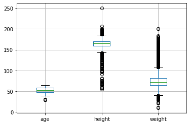

```python
# Plotting boxplots to observe outliers for age, height and weight
mydata.loc[:,("age","height","weight")].boxplot()
```

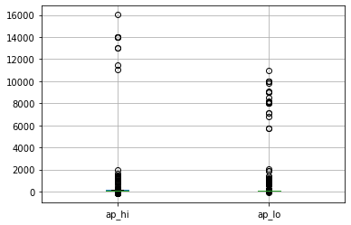

```python
# Plotting boxplots to observe outliers for systolic and diastolic blood pressure
mydata.loc[:,("ap_hi","ap_lo")].boxplot()
```

```python
# Creating a function to inform us about the outliers
def outliers(column):
    """
    Changes the rows with outliers in them to nan type to remove them later.
    """
    q3,q1 = np.percentile(mydata[column],[75,25])
    interquartile = q3-q1

    upper = q3+(1.5*interquartile)
    lower = q1-(1.5*interquartile)

    mydata.loc[mydata[column]<lower,column] = np.nan
    mydata.loc[mydata[column]>upper,column] = np.nan

    print(f"Number of outliers in the column {column} is {mydata[column].isnull().sum()}")
```

```python
# Calling the outliers functions and dropping the rows with outliers in them.
outliers('height')
mydata=mydata.dropna(axis=0)
outliers('weight')
mydata=mydata.dropna(axis=0)
outliers('age')
mydata=mydata.dropna(axis=0)
```

```
Number of outliers in the column height is 519
Number of outliers in the column weight is 1758
Number of outliers in the column age is 4
```

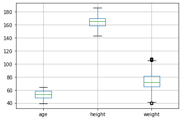

```python
# Plotting boxplots again with outliers removed
mydata.loc[:,("age","height","weight")].boxplot()
```

```python
# Calling the outliers functions for the blood pressures
#temporary fix; need changes
outliers('ap_hi')
mydata=mydata.dropna(axis=0)
outliers('ap_lo')
mydata=mydata.dropna(axis=0)
```

```
Number of outliers in the column ap_hi is 1309
Number of outliers in the column ap_lo is 3908
```

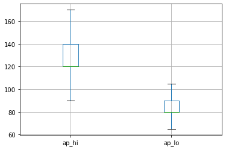

```python
# Plotting boxplots again with outliers removed
mydata.loc[:,("ap_hi","ap_lo")].boxplot()
```

We will now plot for the explanatory variables.

[figure not shown]

```python
plt.figure(figsize=(10,10))
sns.scatterplot(data=mydata, x='ap_hi',y='ap_lo',hue='cardio')
plt.xlabel("Diastolic BP")
plt.ylabel("Systolic BP")
plt.show()
```

There is a higher concentration of orange points (which represents invdivduals with CVD) at the top right of the graph. It is evident from the systolic vs diastolic blood pressure plot that the rates of cardiovascular disease increase with an increase in blood pressure.

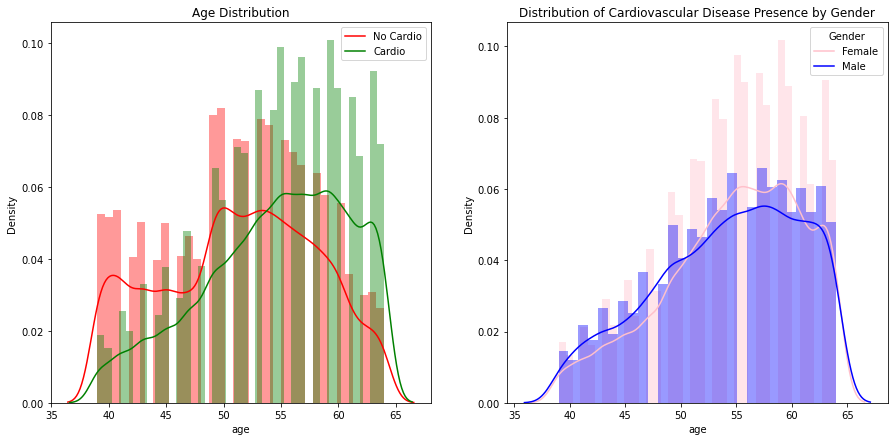

```python
# Some distribution graphs
fig, (ax1, ax2) = plt. subplots (1,2, figsize=(15,7))
noCardio = (mydata['age']) [mydata['cardio']==0]
yesCardio = (mydata['age']) [mydata['cardio']==1]
sns.distplot(noCardio, ax = ax1, color='red')
sns.distplot(yesCardio, ax = ax1, color='green' )
ax1.set_title('Age Distribution')
ax1.legend(labels=["No Cardio","Cardio"])

female = mydata['gender'] == 1
male = mydata['gender'] == 2

sns.distplot(mydata[(mydata.gender==1) & (mydata.cardio==1)]['age'], ax = ax2, color='pink' )
sns.distplot(mydata[(mydata.gender==2) & (mydata.cardio==1)]['age'], ax = ax2, color='blue')
ax2.set_title('Distribution of Cardiovascular Disease Presence by Gender')
ax2.legend(labels=["Female","Male"], title = "Gender")
plt.show()
```

Based on the above Age Distribution, we see that older adults are more likely to suffer from Cardiovascular Disease. Similarly in the distribution of Cardiovascular Disease Presence by Gender, we see that older female adults are more likely to suffer from Cardiovascular Disease. However, from our summary statistics, we note that there are a higher distribution of women to men.

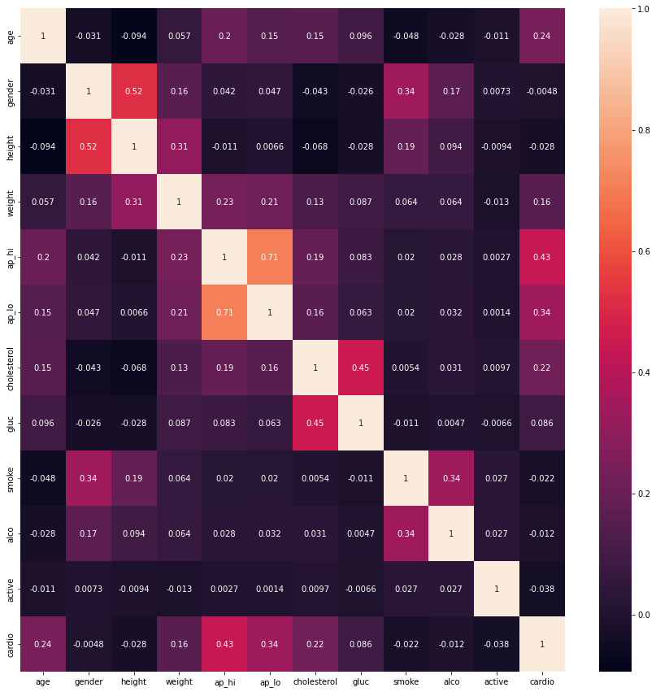

```python
# Plotting a correlation matrix
plt.figure(figsize = (15,15))
corr_matrix = mydata.iloc[:,1:].corr()
sns.heatmap(corr_matrix, annot=True)
plt.show()
```

Most of our variable are uncorrelated expect for the ap_hi and ap_lo. Since these represent systolic and diastolic blood pressure, this behaviour is expected. We dropped ap_lo to prevent multlicolinearity.

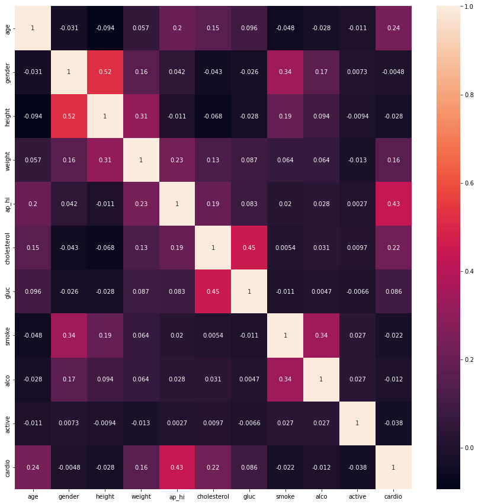

```python
# Correlation matrix after dropping ap_lo
mydata= mydata.drop('ap_lo', axis=1)
plt.figure(figsize = (15,15))
corr_matrix = mydata.iloc[:,1:].corr()
sns.heatmap(corr_matrix, annot=True)
plt.show()
```

### III) Logisitic Regression

We will now attempt to build a logisitic regression model using 'cardio' as our response variable. We will start by splitting the data into training and testing data.

```python
# Train/test split
x=mydata.iloc[:,1:-1]
y=mydata.iloc[:,-1]
xtrain, xtest, ytrain, ytest = train_test_split(x, y, test_size=0.3, random_state=0)
scaler = StandardScaler().fit(xtrain)
xtrain = scaler.transform(xtrain)
xtest = scaler.transform(xtest)
```

```python
# Printing the accuracy of our function of our training/test data
logreg = LogisticRegression()
logreg.fit(xtrain, ytrain)
y_pred = logreg.predict(xtest)
print('Accuracy of logistic regression classifier on test set: {:.2f}'.format(logreg.score(xtest, ytest)))
```

```
Accuracy of logistic regression classifier on test set: 0.72
```

```python
# Downloading a package to help us summarize the results
from sklearn.metrics import classification_report
pd.DataFrame(classification_report(ytest,y_pred,output_dict=True))
```

|  | 0 | 1 | accuracy | macro avg | weighted avg |
| --- | --- | --- | --- | --- | --- |
| precision | 0.699139 | 0.749634 | 0.721188 | 0.724386 | 0.724226 |
| recall | 0.782724 | 0.658866 | 0.721188 | 0.720795 | 0.721188 |
| f1-score | 0.738574 | 0.701325 | 0.721188 | 0.719950 | 0.720068 |
| support | 9435.000000 | 9316.000000 | 0.721188 | 18751.000000 | 18751.000000 |

```
<sklearn.metrics._plot.confusion_matrix.ConfusionMatrixDisplay at 0x1b01a1bc670>
```

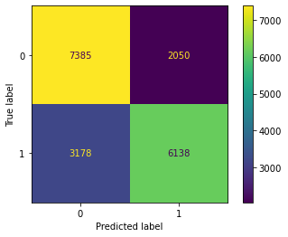

```python
# Printing a confusion matrix
ConfusionMatrixDisplay.from_predictions(ytest, y_pred)
```

```python
import statsmodels.api as sm
logit_model=sm.Logit(y,x)
result=logit_model.fit()
print(result.summary2())
```

```
Optimization terminated successfully.
         Current function value: 0.579643
         Iterations 6
                         Results: Logit
=================================================================
Model:              Logit            Pseudo R-squared: 0.164
Dependent Variable: cardio           AIC:              72477.6460
Date:               2022-12-07 16:53 BIC:              72568.0755
No. Observations:   62502            Log-Likelihood:   -36229.
Df Model:           9                LL-Null:          -43318.
Df Residuals:       62492            LLR p-value:      0.0000
Converged:          1.0000           Scale:            1.0000
No. Iterations:     6.0000
------------------------------------------------------------------
              Coef.   Std.Err.     z      P>|z|    [0.025   0.975]
------------------------------------------------------------------
age           0.0311    0.0013   23.5760  0.0000   0.0285   0.0336
gender        0.3399    0.0215   15.8308  0.0000   0.2978   0.3819
height       -0.0645    0.0007  -88.1894  0.0000  -0.0660  -0.0631
weight        0.0170    0.0008   21.1985  0.0000   0.0154   0.0186
ap_hi         0.0561    0.0007   76.9351  0.0000   0.0547   0.0576
cholesterol   0.4738    0.0161   29.4389  0.0000   0.4423   0.5054
gluc         -0.1440    0.0183   -7.8871  0.0000  -0.1798  -0.1083
smoke        -0.1005    0.0358   -2.8073  0.0050  -0.1706  -0.0303
alco         -0.1984    0.0437   -4.5431  0.0000  -0.2840  -0.1128
active       -0.3207    0.0225  -14.2513  0.0000  -0.3648  -0.2766
=================================================================
```

Since all of the predictors appear to be siginicant for any common value for alpha, the feature which stands out the most in this model is cholestrol. The large positive coefficent of cholestrol, and small p-value, imply that an increase in choloestrol level results in an incresease suseptibilty to cardiovascular disease. In the next part of our project, we will use the spoonacular api to check if the most popular food consumed by American's have high amounts of cholesterol, therby increasing their susceptibilty to cardiovascular diseases.

### V) Linear Regression

We will now attempt to construct a linear model with the nutritional facts of frozen foods to determine if there are any relationships there to better understand how nutritional facts are constructed. We will also attempt to answer the question of if there is a higher concentration of cholesterol in [deli meats](https://www.verywellhealth.com/deli-meats-for-cholesterol-lowering-diet-698097#:~:text=Deli%20meat%20can%20be%20high,lower%20in%20fat%20and%20cholesterol.) to further support what we have found in the logistic regression modeling.

**API Data Collection**

```python
# Some useful packages
import pandas as pd
import numpy as np
import seaborn as sns
import matplotlib.pyplot as plt
```

```python
# API related packages
import requests
import sqlite3 as sql
import time
import warnings
```

```python
# Making a function for reading the key
def read_key(keyfile):
    with open(keyfile) as f:
        return f.readline().strip("\n")
```

```python
# Reading in the key and making the needed header
key = read_key("key2.txt")
header = {'Content-Type': 'application/json'}
```

The API is documented in such a way in where in order to obtain the nutritional information of a food product, you need to have the ID number. To get the nutritional information, we are going to first query for a list of links to food products that include the ID numbers, and then create a data frame containing the product name along with the nutritional values.

```python
# Requesting a list of links to with the query "Frozen Dinner"
response = requests.get("https://api.spoonacular.com/food/products/search", headers= header,
                        params = {
                            "apiKey": key,
                            "query": "Frozen Dinner",
                            "number": 50
})
```

```python
# Compiling into a json format
result = response.json()
```

```python
# Putting the links into a pandas data frame that is easier for us to read
links = pd.DataFrame(result['products'])
links.head()
```

|  | id | title | image | imageType |
| --- | --- | --- | --- | --- |
| 0 | 92258 | Kid Cuisine Pop Star Popcorn Chicken Frozen Me... | https://spoonacular.com/productImages/92258-31... | jpeg |
| 1 | 178416 | Stouffer's Baked Chicken Frozen Meal 8.875 oz. | https://spoonacular.com/productImages/178416-3... | jpeg |
| 2 | 66713 | Smart Ones Chicken Strips &amp; Ranch Seasoned... | https://spoonacular.com/productImages/66713-31... | jpeg |
| 3 | 51230 | Stouffer's Macaroni &amp; Cheese Frozen Meal 1... | https://spoonacular.com/productImages/51230-31... | jpeg |
| 4 | 51183 | Banquet Family Size Zesty Marinara Sauce Over ... | https://spoonacular.com/productImages/51183-31... | jpeg |

```python
# Converting the ID number into a string to use for our query
links["id"] = links["id"].astype(str)
# Making an arry of the link ID strings
links_frozen = np.array(links["id"])
```

Now that the links with the products' ID have been obtained, we will now define a function to help us obtain each of the nutritonal facts from each product.

```python
# Defining our information retrieval function
def get_information(links):
    total = pd.DataFrame()
    prices = []
    time.sleep(0.05)
    # For each product
    for y in range(links.size):
        link = "https://api.spoonacular.com/food/products/" + links[y]
        response = requests.get(link, headers = header, params = {
            "apiKey": key
        })
        result = response.json()
        prices.append(result['price'])
        thing = pd.DataFrame(dict([ (k,pd.Series(v)) for k,v in result['nutrition'].items()]))
        # Dropping some rows that do not have many values
        thing = thing.drop('percentCarbs').drop('percentFat').drop('percentProtein')
        df = pd.DataFrame()
        # For each nutritional value in the product
        for x in range(len(thing.index)):
            df1 = pd.DataFrame.from_dict(thing.iloc[x,0], orient = 'index').T
            df = df.append(df1)
        append_frame = pd.DataFrame({"Data":[df], "Name": result['title']})
        total = total.append(append_frame)
    total["Price"] = prices
    return total
```

```python
# Collecting the data
warnings.filterwarnings('ignore')
data_info = get_information(links_frozen)
```

```python
# Showing the data frame returned from the function
data_info.head()
```

|  | Data | Name | Price |
| --- | --- | --- | --- |
| 0 | name amount unit percentOfDai... | Kid Cuisine Pop Star Popcorn Chicken Frozen Me... | 1.84 |
| 0 | name amount unit percentOfDai... | Stouffer's Classics Baked Chicken Breast - Bon... | 439.00 |
| 0 | name amount unit percentOfDai... | Smart Ones Chicken Strips &amp; Ranch Seasoned... | 0.75 |
| 0 | name amount unit percentOfDai... | Stouffer's Simple Dishes Macaroni & Cheese - F... | 2.24 |
| 0 | name amount unit percentOfDai... | Banquet Family Size Zesty Marinara Sauce Over ... | 399.00 |

```python
# Getting the columns for the nutritional value
data_columns = np.array(data_info.iloc[1,0].iloc[:,0])
# Getting the names of the products and calling it the index
data_index = np.array(data_info.iloc[:,1])
# Creating a data frame with the most common nutritional values
products = pd.DataFrame(columns = data_columns[0:12])
# Adding products to our new nutritional data frame
for z in range(data_index.size):
    splicer = np.array(data_info.iloc[z,0].iloc[:,3])
    splicer = splicer[0:12]
    products.loc[z] = splicer
# Adding the product name as our index
products = products.set_axis(data_index, axis = 0)
# Converting our products as numerical values
products = products.astype(float)
```

```python
# Displaying the first products and their nutritional values
products.head()
```

|  | Calcium | Carbohydrates | Cholesterol | Calories | Fat | Saturated Fat | Trans Fat | Fiber | Iron | Protein | Sodium | Sugar |
| --- | --- | --- | --- | --- | --- | --- | --- | --- | --- | --- | --- | --- |
| Kid Cuisine Pop Star Popcorn Chicken Frozen Meal With Corn, French Fries &amp; Strawberry Cake, 8.65 oz. | 6.0 | 22.00 | 6.67 | 22.5 | 21.54 | 15.63 | 5000.0 | 24.0 | 25.0 | 10.0 | 15.00 | 35.00 |
| Stouffer's Classics Baked Chicken Breast - Boneless chicken breast with gravy and mashed potatoes | 4.0 | 5.67 | 25.00 | 12.0 | 9.23 | 15.63 | 0.0 | 4.0 | 4.0 | 48.0 | 33.04 | 1.11 |
| Smart Ones Chicken Strips &amp; Ranch Seasoned Fries Frozen Meal, 4.72 oz Box | 0.0 | 10.00 | 11.67 | 15.5 | 23.08 | 18.75 | 0.0 | 8.0 | 6.0 | 28.0 | 22.17 | 0.00 |
| Stouffer's Simple Dishes Macaroni & Cheese - Freshly made pasta in a 100% Real Cheddar cheese sauce | 30.0 | 10.67 | 8.33 | 16.5 | 24.62 | 43.75 | 5000.0 | 8.0 | 4.0 | 26.0 | 35.22 | 4.44 |
| Banquet Family Size Zesty Marinara Sauce Over Meatballs, Frozen Meal, 25 OZ | 8.0 | 3.00 | 13.33 | 10.0 | 20.00 | 25.00 | 5000.0 | 12.0 | 8.0 | 10.0 | 8.00 | 15.00 |

**Linear Model Building**

Now we have obtained our data in a more accessible format. The variables we looked to include to our model are calcium, carbohydrates, cholesterol, calories, fat, saturated fats, trans fat, fiber, iron, protein, sodium, and sugar. We took the percentages of the daily needs of each nutritional fact rather than its actual measurement due to how some were measures in differently (for example trans fat was measures in mg and fat in g). Additionally, some of the nutritients are to be consumed in different amounts according the [CDC](https://www.cdc.gov/healthyweight/healthy_eating/index.html) and what goes into a standard 2,000 calorie diet. We now are going to see if we can run a linear model with calories as our response variable.

```python
# Importing some more packages
import statsmodels.api as sm
import plotnine as p9
```

```python
# Adding a constant and creating some data frames for us to use for boxplots
products = sm.add_constant(products)
products2 = products.drop(columns = ['Trans Fat', 'Fiber', 'const'])
products3 = products['Trans Fat']
products4 = products['Fiber']
```

```python
# Stacking the data for boxplots
products_plt = products2.set_index("Calories").stack().reset_index()
products_plt.columns.values[[1,2]] = np.array(['key', 'value'])
```

[output not shown]

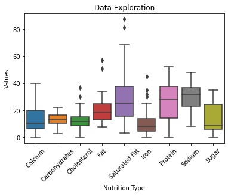

```python
# Plotting the boxplots for nutritional values for variables
ax = sns.boxplot(x = "key", y = "value", data = products_plt)
ax.set(title = "Data Exploration", xlabel = "Nutrition Type", ylabel = "Values")
ax.set_xticklabels(ax.get_xticklabels(), rotation = 45)
```

```python
corr = products.corr()
corr.style.background_gradient(cmap='coolwarm')
```

|  | const | Calcium | Carbohydrates | Cholesterol | Calories | Fat | Saturated Fat | Trans Fat | Fiber | Iron | Protein | Sodium | Sugar |
| --- | --- | --- | --- | --- | --- | --- | --- | --- | --- | --- | --- | --- | --- |
| const | nan | nan | nan | nan | nan | nan | nan | nan | nan | nan | nan | nan | nan |
| Calcium | nan | 1.000000 | 0.065992 | -0.098259 | 0.160789 | 0.159804 | 0.384616 | -0.090190 | -0.112635 | -0.159273 | 0.104603 | 0.274424 | -0.194498 |
| Carbohydrates | nan | 0.065992 | 1.000000 | -0.127196 | 0.643475 | 0.191054 | 0.046423 | -0.097077 | 0.177409 | 0.420620 | -0.008380 | -0.187042 | 0.372447 |
| Cholesterol | nan | -0.098259 | -0.127196 | 1.000000 | 0.310626 | 0.396606 | 0.486759 | 0.197270 | -0.028831 | 0.128775 | 0.382568 | 0.229888 | -0.108312 |
| Calories | nan | 0.160789 | 0.643475 | 0.310626 | 1.000000 | 0.777089 | 0.669950 | 0.169243 | -0.239830 | 0.302658 | 0.245982 | 0.227499 | 0.098982 |
| Fat | nan | 0.159804 | 0.191054 | 0.396606 | 0.777089 | 1.000000 | 0.883109 | 0.353348 | -0.027185 | 0.209537 | 0.344462 | 0.303629 | -0.192126 |
| Saturated Fat | nan | 0.384616 | 0.046423 | 0.486759 | 0.669950 | 0.883109 | 1.000000 | 0.181170 | -0.134866 | 0.096554 | 0.412026 | 0.459231 | -0.309532 |
| Trans Fat | nan | -0.090190 | -0.097077 | 0.197270 | 0.169243 | 0.353348 | 0.181170 | 1.000000 | -0.063933 | 0.037175 | -0.043664 | 0.017124 | -0.066235 |
| Fiber | nan | -0.112635 | 0.177409 | -0.028831 | -0.239830 | -0.027185 | -0.134866 | -0.063933 | 1.000000 | 0.333324 | 0.191672 | -0.277420 | -0.039047 |
| Iron | nan | -0.159273 | 0.420620 | 0.128775 | 0.302658 | 0.209537 | 0.096554 | 0.037175 | 0.333324 | 1.000000 | -0.045711 | -0.341483 | 0.322179 |
| Protein | nan | 0.104603 | -0.008380 | 0.382568 | 0.245982 | 0.344462 | 0.412026 | -0.043664 | 0.191672 | -0.045711 | 1.000000 | 0.409198 | -0.737049 |
| Sodium | nan | 0.274424 | -0.187042 | 0.229888 | 0.227499 | 0.303629 | 0.459231 | 0.017124 | -0.277420 | -0.341483 | 0.409198 | 1.000000 | -0.406618 |
| Sugar | nan | -0.194498 | 0.372447 | -0.108312 | 0.098982 | -0.192126 | -0.309532 | -0.066235 | -0.039047 | 0.322179 | -0.737049 | -0.406618 | 1.000000 |

```python
# Converting the data for the plotnine graphs
products_plt = products.set_index("Calories").stack().reset_index()
products_plt.columns.values[[1,2]] = np.array(['key', 'value'])
```

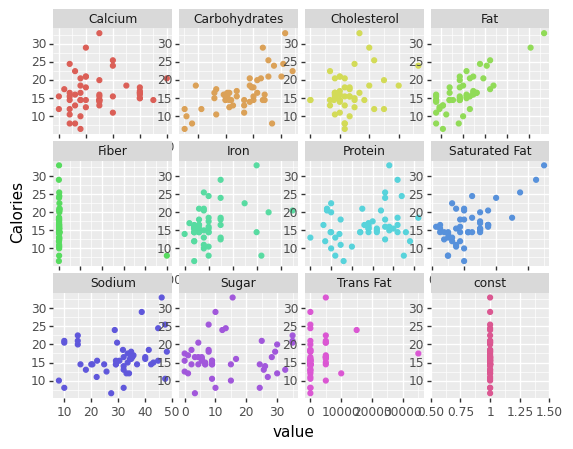

```python
# Plotting all the predictors against Calories
(
    p9.ggplot(products_plt, p9.aes(x = "value", y = "Calories", color = "key"))
    + p9.geom_point()
    + p9.facet_wrap("key", scales = "free")
    + p9.scale_color_discrete(guide=False)
)
```

```python
# Fitting a linear model with calories as a response
ols = sm.OLS(products['Calories'], products.drop(columns = 'Calories')) #Initialize the OLS
ols_res = ols.fit()
```

```python
# Printing the results from our function
print(ols_res.summary())
```

```
                            OLS Regression Results
==============================================================================
Dep. Variable:               Calories   R-squared:                       0.985
Model:                            OLS   Adj. R-squared:                  0.981
Method:                 Least Squares   F-statistic:                     234.4
Date:                Wed, 07 Dec 2022   Prob (F-statistic):           2.24e-31
Time:                        16:55:16   Log-Likelihood:                -45.532
No. Observations:                  50   AIC:                             115.1
Df Residuals:                      38   BIC:                             138.0
Df Model:                          11
Covariance Type:            nonrobust
=================================================================================
                    coef    std err          t      P>|t|      [0.025      0.975]
---------------------------------------------------------------------------------
const            -0.1665      0.587     -0.284      0.778      -1.355       1.022
Calcium           0.0066      0.013      0.496      0.623      -0.020       0.034
Carbohydrates     0.5686      0.029     19.646      0.000       0.510       0.627
Cholesterol       0.0651      0.022      2.925      0.006       0.020       0.110
Fat               0.3055      0.030     10.317      0.000       0.246       0.365
Saturated Fat    -0.0120      0.019     -0.646      0.522      -0.050       0.026
Trans Fat     -1.187e-05   2.19e-05     -0.542      0.591   -5.62e-05    3.25e-05
Fiber            -0.0025      0.000    -15.199      0.000      -0.003      -0.002
Iron              0.0199      0.014      1.432      0.160      -0.008       0.048
Protein           0.0622      0.016      3.942      0.000       0.030       0.094
Sodium            0.0168      0.012      1.365      0.180      -0.008       0.042
Sugar             0.0570      0.019      2.961      0.005       0.018       0.096
==============================================================================
Omnibus:                       13.779   Durbin-Watson:                   1.749
Prob(Omnibus):                  0.001   Jarque-Bera (JB):               22.797
Skew:                          -0.791   Prob(JB):                     1.12e-05
Kurtosis:                       5.905   Cond. No.                     3.69e+04
==============================================================================

Notes:
[1] Standard Errors assume that the covariance matrix of the errors is correctly specified.
[2] The condition number is large, 3.69e+04. This might indicate that there are
strong multicollinearity or other numerical problems.
```

```python
# Importing a package for VIF
from statsmodels.stats.outliers_influence import variance_inflation_factor
```

```python
# Removing calories and making a dataframe for VIF
products1 = products.drop(columns = 'Calories')
# VIF dataframe
vif_data = pd.DataFrame()
vif_data["feature"] = products1.columns

# calculating VIF for each feature
vif_data["VIF"] = [variance_inflation_factor(products1.values, i)
                          for i in range(len(products1.columns))]
print(vif_data)
```

```
          feature        VIF
0           const  36.191659
1         Calcium   1.875936
2   Carbohydrates   2.016059
3     Cholesterol   2.309144
4             Fat   9.392979
5   Saturated Fat  12.096993
6       Trans Fat   1.575038
7           Fiber   1.401843
8            Iron   1.717367
9         Protein   4.636021
10         Sodium   1.797592
11          Sugar   4.547696
```

There appears to be no signs of major multicollinearity excluding the variables saturated fats and constant. However, when running a smaller model including only significant predictors, we could recalculate VIF on the subsetted dataframe and see if there is any variables with high VIF's.

We now will show the Q-Q plot and Fitted vs Residuals plot to determine if any of the assumptions are violated. We will also use density plot to determine if calories are distributed normally.

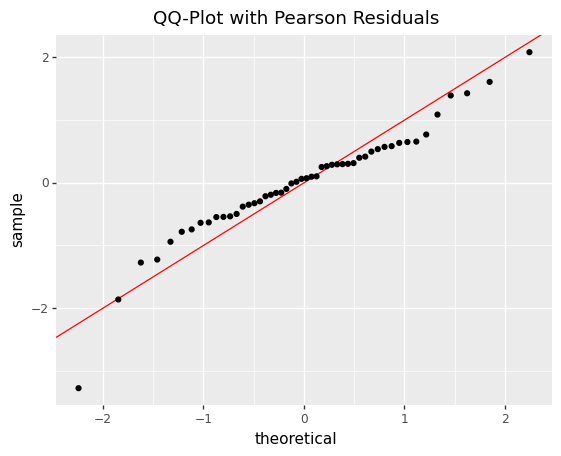

```python
(
    p9.ggplot(mapping = p9.aes(sample = "ols_res.resid_pearson"))
    + p9.geom_abline(p9.aes(intercept = 0, slope = 1), color = 'red')
    + p9.stats.stat_qq()
    + p9.labs(title = "QQ-Plot with Pearson Residuals")
)
```

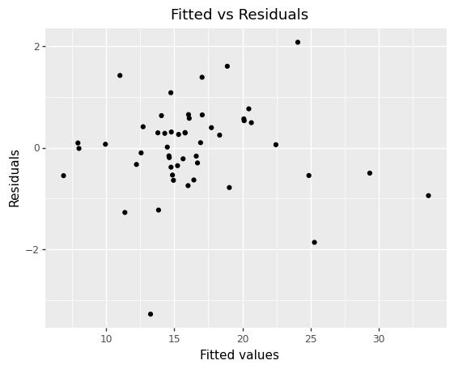

```python
(
    p9.ggplot(mapping = p9.aes(x = 'ols_res.fittedvalues',
                                            y = "ols_res.resid_pearson"))
    + p9.geom_point()
    + p9.labs(title = "Fitted vs Residuals", x = 'Fitted values', y = 'Residuals')
)
```

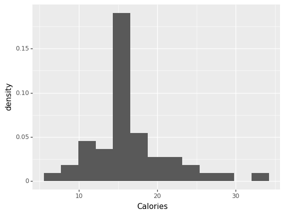

```python
(
    p9.ggplot(data = products, mapping = p9.aes(x = 'Calories'))
    + p9.geom_histogram(p9.aes(y = "..density.."))
)
```

What we observed is the QQ plot of the residuals shows that the residuals roughly lie along the straight line, which indicates that the normality assumption holds. Additionally, the Fitted vs Residuals plot shows no pattern that indicates constant variance assumption. Finally the distribution of the response variable looks roughly symmetric and therefore does not need to be transformed.

### Smaller Model

```python
products2 = products.drop(columns = ['Calcium', 'Saturated Fat', 'Trans Fat', 'Iron', 'Sodium'])
products2.head()
```

|  | const | Carbohydrates | Cholesterol | Calories | Fat | Fiber | Protein | Sugar |
| --- | --- | --- | --- | --- | --- | --- | --- | --- |
| Kid Cuisine Pop Star Popcorn Chicken Frozen Meal With Corn, French Fries &amp; Strawberry Cake, 8.65 oz. | 1.0 | 22.00 | 6.67 | 22.5 | 21.54 | 24.0 | 10.0 | 35.00 |
| Stouffer's Classics Baked Chicken Breast - Boneless chicken breast with gravy and mashed potatoes | 1.0 | 5.67 | 25.00 | 12.0 | 9.23 | 4.0 | 48.0 | 1.11 |
| Smart Ones Chicken Strips &amp; Ranch Seasoned Fries Frozen Meal, 4.72 oz Box | 1.0 | 10.00 | 11.67 | 15.5 | 23.08 | 8.0 | 28.0 | 0.00 |
| Stouffer's Simple Dishes Macaroni & Cheese - Freshly made pasta in a 100% Real Cheddar cheese sauce | 1.0 | 10.67 | 8.33 | 16.5 | 24.62 | 8.0 | 26.0 | 4.44 |
| Banquet Family Size Zesty Marinara Sauce Over Meatballs, Frozen Meal, 25 OZ | 1.0 | 3.00 | 13.33 | 10.0 | 20.00 | 12.0 | 10.0 | 15.00 |

```python
ols_small = sm.OLS(products['Calories'], products2.drop(columns = ['Calories'])) #Initialize the OLS
ols_small_res = ols_small.fit()
```

```python
print(ols_small_res.summary())
```

```
                            OLS Regression Results
==============================================================================
Dep. Variable:               Calories   R-squared:                       0.984
Model:                            OLS   Adj. R-squared:                  0.982
Method:                 Least Squares   F-statistic:                     445.9
Date:                Wed, 07 Dec 2022   Prob (F-statistic):           4.92e-37
Time:                        16:55:39   Log-Likelihood:                -47.666
No. Observations:                  50   AIC:                             109.3
Df Residuals:                      43   BIC:                             122.7
Df Model:                           6
Covariance Type:            nonrobust
=================================================================================
                    coef    std err          t      P>|t|      [0.025      0.975]
---------------------------------------------------------------------------------
const             0.2098      0.458      0.458      0.650      -0.715       1.134
Carbohydrates     0.5757      0.027     21.347      0.000       0.521       0.630
Cholesterol       0.0598      0.019      3.174      0.003       0.022       0.098
Fat               0.2933      0.011     26.065      0.000       0.271       0.316
Fiber            -0.0025      0.000    -17.296      0.000      -0.003      -0.002
Protein           0.0692      0.014      4.827      0.000       0.040       0.098
Sugar             0.0639      0.018      3.633      0.001       0.028       0.099
==============================================================================
Omnibus:                       15.687   Durbin-Watson:                   1.872
Prob(Omnibus):                  0.000   Jarque-Bera (JB):               35.189
Skew:                          -0.755   Prob(JB):                     2.29e-08
Kurtosis:                       6.823   Cond. No.                     3.39e+03
==============================================================================

Notes:
[1] Standard Errors assume that the covariance matrix of the errors is correctly specified.
[2] The condition number is large, 3.39e+03. This might indicate that there are
strong multicollinearity or other numerical problems.
```

Fitting a reduced model on the subset of the predictors give us small p-values which indicate that all predictors are significant. The adjusted R-squared value is 0.982. More importantly, Akaike information criterion for the reduced model is lower compared to the full model, i.e. 115.1 vs 109.3, which may indicate a better fit. Because of the rule of parsimony, if smaller model performs just as good as the full model, we should choose the smaller model.

```python
products2 = products2.drop(columns = ['Calories'])
# VIF dataframe
vif_data = pd.DataFrame()
vif_data["feature"] = products2.columns

# calculating VIF for each feature
vif_data["VIF"] = [variance_inflation_factor(products2.values, i)
                          for i in range(len(products2.columns))]


print(vif_data)
```

```
         feature        VIF
0          const  22.937307
1  Carbohydrates   1.818949
2    Cholesterol   1.717723
3            Fat   1.409012
4          Fiber   1.108979
5        Protein   3.978300
6          Sugar   3.947170
```

After computing the VIF for our smaller model, we do not find any variables to be highly correlated. We are ignoring the const variable as it is our intercept.

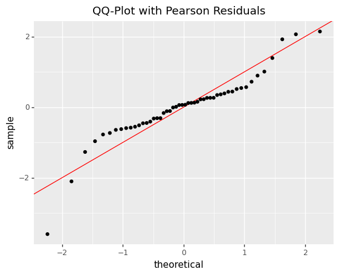

```python
(
    p9.ggplot(mapping = p9.aes(sample = "ols_small_res.resid_pearson"))
    + p9.geom_abline(p9.aes(intercept = 0, slope = 1), color = 'red')
    + p9.stats.stat_qq()
    + p9.labs(title = "QQ-Plot with Pearson Residuals")
)
```

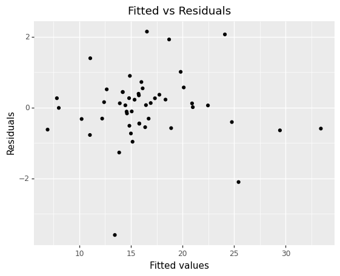

```python
(
    p9.ggplot(mapping = p9.aes(x = 'ols_small_res.fittedvalues',
                                            y = "ols_small_res.resid_pearson"))
    + p9.geom_point()
    + p9.labs(title = "Fitted vs Residuals", x = 'Fitted values', y = 'Residuals')
)
```

The assumptions seem to hold with our smaller models as the Q-Q plot shows the residuals holding roughly a straight line. Additionally the residual plot shows no distinct pattern once again.

**Querying for Lunch Meats**

Now that we have a better understanding to which of the predictors contribute most towards calories, we now wish to see if the claim that [deli meats](https://www.verywellhealth.com/deli-meats-for-cholesterol-lowering-diet-698097#:~:text=Deli%20meat%20can%20be%20high,lower%20in%20fat%20and%20cholesterol.) actually have a higher concentration of cholesterol per calorie compared to the reccomended daily intake that is reccomended.

```python
# Querying a response of links for deli meats
response = requests.get("https://api.spoonacular.com/food/products/search",headers= header,
                        params = {
                            "apiKey": key,
                            "query": "Deli Meats",
                            "number": 50
})
```

```python
# Making the id numbers strings
result = response.json()
links = pd.DataFrame(result['products'])
links["id"] = links["id"].astype(str)
links_frozen = links["id"].tolist()
```

```python
# This link proves to be a bad link, as it contains no information
links_frozen.remove('609693')
```

```python
# Further cleaning
links = links.drop(['image','imageType'], axis=1)
links = links.drop(labels=27,axis=0)
links_meat = links.id.tolist()
```

```python
# Defining a function to retrieve the nutritional fact for cholesterol
def get_nut(id):
    time.sleep(0.05)
    nut_response = requests.get(f'https://api.spoonacular.com/food/products/{id}', headers=header,
    params = {
    "apiKey": key,
    "query": "Deli Meats",
    "number": 50
    })
    nut_response = nut_response.json()
    # querying cholestrol stuff
    for i in nut_response['nutrition']['nutrients']:
        if i['name']=='Calories':
            cal = i['amount']
        if i['name']=='Cholesterol':
            chol, per_daily= (i['amount'],i['percentOfDailyNeeds'])
    return id,cal,chol,per_daily
```

```python
# Using the function
chol_list = []
daily_per_list = []
cal_list =[]
id_list =[]
bad_ids = []
for j in links_meat:
    if get_nut(j)==None:
        bad_ids.append(j)
        continue
    id,cal,chol,daily_per = get_nut(j)

    chol_list.append(chol)
    daily_per_list.append(daily_per)
    cal_list.append(cal)
    id_list.append(id)
```

```python
# This originally returned the bad link as stated before, for simplicity sake it is empty here
bad_ids
```

```
[]
```

```python
# Making a data frame with the necessary values
cholestrol_api = pd.DataFrame({
    'id': id_list,
    'Cholesterol(mg)': chol_list,
    'PercentageIntakeCholesterol': daily_per_list,
    'Calories':cal_list
     })

cholestrol_api.head()
```

|  | id | Cholesterol(mg) | PercentageIntakeCholesterol | Calories |
| --- | --- | --- | --- | --- |
| 0 | 132346 | 30.0 | 10.00 | 60.0 |
| 1 | 212641 | 30.0 | 10.00 | 45.0 |
| 2 | 207773 | 30.0 | 10.00 | 60.0 |
| 3 | 178027 | 15.0 | 5.00 | 350.0 |
| 4 | 115795 | 50.0 | 16.67 | 370.0 |

```python
# Merging the function
final_df = pd.merge(cholestrol_api,links, on='id')
final_df.head()
```

|  | id | Cholesterol(mg) | PercentageIntakeCholesterol | Calories | title |
| --- | --- | --- | --- | --- | --- |
| 0 | 132346 | 30.0 | 10.00 | 60.0 | Applegate Naturals Chicken Breast Oven Roasted... |
| 1 | 212641 | 30.0 | 10.00 | 45.0 | Hormel Oven Roasted Chicken Breast, in Broth, ... |
| 2 | 207773 | 30.0 | 10.00 | 60.0 | Applegate Organics® Smoked Chicken Breast 6 oz... |
| 3 | 178027 | 15.0 | 5.00 | 350.0 | Celeste Pepperoni Pizza for One, Individual Mi... |
| 4 | 115795 | 50.0 | 16.67 | 370.0 | Palermo's Primo Thin Pizza Pepperoni |

```python
# Dropping entries that contained deli meats but are actually either pizza entries/P3 protein snack
mask = final_df["title"].str.contains("Pizza|Portable|Diced")
filtered_df = final_df[~mask]
final_df.drop(final_df[mask].index, inplace=True)
final_df.head()
```

|  | id | Cholesterol(mg) | PercentageIntakeCholesterol | Calories | title |
| --- | --- | --- | --- | --- | --- |
| 0 | 132346 | 30.0 | 10.0 | 60.0 | Applegate Naturals Chicken Breast Oven Roasted... |
| 1 | 212641 | 30.0 | 10.0 | 45.0 | Hormel Oven Roasted Chicken Breast, in Broth, ... |
| 2 | 207773 | 30.0 | 10.0 | 60.0 | Applegate Organics® Smoked Chicken Breast 6 oz... |
| 6 | 43395 | 30.0 | 10.0 | 60.0 | Oscar Mayer Natural Slow Roasted Chicken Breas... |
| 7 | 14406 | 60.0 | 20.0 | 90.0 | Perdue Grilled Chicken Breast Short Cuts (9 oz.) |

```python
# Adding a column that provides ratio of mg of cholesterol to calorie
final_df = final_df.assign(Chol_Cal = final_df['Cholesterol(mg)']/final_df['Calories'])
```

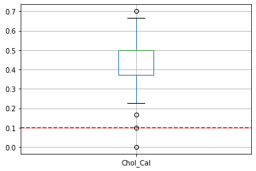

```python
# Plotting a boxplot of the distribution of the ratio and a line indicating the reccomended amount
final_df.boxplot(column='Chol_Cal')
plt.axhline(y=0.1,color ='r', linestyle='--')
plt.show()
```

As seen from the boxplot, the cholesterol content per calorie for processed deli meats are much higher than the recommended intake (denoted by the red dashed line). The lower tail, and the median, is much higher than what is [recommended](https://www.ucsfhealth.org/education/cholesterol-content-of-foods#:~:text=If%20you%20have%20risk%20factors,than%20300%20milligrams%20a%20day.) which sits at 200mg of cholesterol a day if one has risk factors for heart disease or CVD.

### VI) Conclusion

Additionally, it appeared through the use of plots that older women may be more susceptible to cardiovascular disease. Further analysis would need to be done if there is a difference between men and women, with age as well, for the risk of cardiovascular disease. It can be noted that the proportion of women to men was uneven before the data cleaning, which may account to the apparent difference chance for cardiovascular disease for men and women.

From our linear regression model building, we first queried for food products, from the API documented website Spoonacular, under the category for frozen meals to determine if there was a relationship between the calorie count and the nutritional values. We discovered the significant variables be carbohydrates, cholesterol, fat, fiber, protein, and sugar for the response variable of calories. We tested for normality, constant variance and the distribution of the response variable and found that transformations were not needed in this case. We attempted to build a smaller model, just including the aformentioned significant predictors, and found that its Akaike information criterion was smaller/better than the original model. We then determined that the model to be used would be the smaller model (rule of parsimony).

Some possible dissentions include the origin of the kaggle dataset. The publisher of the dataset did not provide information regarding how the data was collected or where it came from. We therefore can not say with full confidence that the findings based on the logisitic regression model are to be accurate and true.

### Links/Sources

https://www.cdc.gov/healthyweight/healthy_eating/index.html

https://www.cdc.gov/obesity/data/prevalence-maps.html

https://spoonacular.com/ **- API Data**

https://www.kaggle.com/datasets/sulianova/cardiovascular-disease-dataset **- CSV Data**

https://www.foodnavigator-usa.com/Article/2022/01/13/Millennials-drive-growth-of-frozen-foods-category-sparked-by-interest-in-premium-challenger-brands

https://www.hsph.harvard.edu/obesity-prevention-source/obesity-consequences/health-effects/#:~:text=Obesity%20increases%20the%20risk%20of,changes%20in%20hormones%20and%20metabolism

https://www.verywellhealth.com/deli-meats-for-cholesterol-lowering-diet-698097#:~:text=Deli%20meat%20can%20be%20high,lower%20in%20fat%20and%20cholesterol

https://www.ucsfhealth.org/education/cholesterol-content-of-foods#:~:text=If%20you%20have%20risk%20factors,than%20300%20milligrams%20a%20day